# Risk Factor Analysis

## Outcome Variable

**Outcome Variable:** haz

## Predictor Variables

**Intervention Variable:** vagbrth

**Adjustment Set:**

- arm
- sex
- W_mage
- meducyrs
- feducyrs
- hhwealth_quart
- W_mhtcm
- W_mwtkg
- W_mbmi
- single
- W_nrooms
- brthmon
- W_parity
- impfloor
- delta_W_mage
- delta_meducyrs
- delta_feducyrs
- delta_hhwealth_quart
- delta_W_mhtcm
- delta_W_mwtkg
- delta_W_mbmi
- delta_single
- delta_W_nrooms
- delta_brthmon
- delta_W_parity
- delta_impfloor

## Stratifying Variables

The analysis was stratified on these variable(s):

- agecat
- studyid
- country

## Data Summary

| agecat | studyid | country | vagbrth | n_cell | n |
| --- | --- | --- | --- | --- | --- |
| Birth | CMC-V-BCS-2002 | INDIA | 0 | 11 | 92 |
| Birth | CMC-V-BCS-2002 | INDIA | 1 | 81 | 92 |
| Birth | IRC | INDIA | 0 | 68 | 388 |
| Birth | IRC | INDIA | 1 | 320 | 388 |
| Birth | JiVitA-3 | BANGLADESH | 0 | 539 | 22418 |
| Birth | JiVitA-3 | BANGLADESH | 1 | 21879 | 22418 |
| Birth | JiVitA-4 | BANGLADESH | 0 | 76 | 2822 |
| Birth | JiVitA-4 | BANGLADESH | 1 | 2746 | 2822 |
| Birth | NIH-Crypto | BANGLADESH | 0 | 186 | 477 |
| Birth | NIH-Crypto | BANGLADESH | 1 | 291 | 477 |
| Birth | PROBIT | BELARUS | 0 | 1597 | 13893 |
| Birth | PROBIT | BELARUS | 1 | 12296 | 13893 |
| Birth | PROVIDE | BANGLADESH | 0 | 108 | 539 |
| Birth | PROVIDE | BANGLADESH | 1 | 431 | 539 |
| Birth | ZVITAMBO | ZIMBABWE | 0 | 1166 | 13761 |
| Birth | ZVITAMBO | ZIMBABWE | 1 | 12595 | 13761 |
| 6 months | CMC-V-BCS-2002 | INDIA | 0 | 25 | 369 |
| 6 months | CMC-V-BCS-2002 | INDIA | 1 | 344 | 369 |
| 6 months | IRC | INDIA | 0 | 69 | 407 |
| 6 months | IRC | INDIA | 1 | 338 | 407 |
| 6 months | JiVitA-3 | BANGLADESH | 0 | 1077 | 16732 |
| 6 months | JiVitA-3 | BANGLADESH | 1 | 15655 | 16732 |
| 6 months | JiVitA-4 | BANGLADESH | 0 | 336 | 4052 |
| 6 months | JiVitA-4 | BANGLADESH | 1 | 3716 | 4052 |
| 6 months | NIH-Crypto | BANGLADESH | 0 | 187 | 457 |
| 6 months | NIH-Crypto | BANGLADESH | 1 | 270 | 457 |
| 6 months | PROBIT | BELARUS | 0 | 1799 | 15760 |
| 6 months | PROBIT | BELARUS | 1 | 13961 | 15760 |
| 6 months | PROVIDE | BANGLADESH | 0 | 139 | 604 |
| 6 months | PROVIDE | BANGLADESH | 1 | 465 | 604 |
| 6 months | TanzaniaChild2 | TANZANIA, UNITED REPUBLIC OF | 0 | 189 | 2005 |
| 6 months | TanzaniaChild2 | TANZANIA, UNITED REPUBLIC OF | 1 | 1816 | 2005 |
| 6 months | ZVITAMBO | ZIMBABWE | 0 | 740 | 8601 |
| 6 months | ZVITAMBO | ZIMBABWE | 1 | 7861 | 8601 |
| 24 months | CMC-V-BCS-2002 | INDIA | 0 | 24 | 371 |
| 24 months | CMC-V-BCS-2002 | INDIA | 1 | 347 | 371 |
| 24 months | IRC | INDIA | 0 | 69 | 409 |
| 24 months | IRC | INDIA | 1 | 340 | 409 |
| 24 months | JiVitA-3 | BANGLADESH | 0 | 480 | 8584 |
| 24 months | JiVitA-3 | BANGLADESH | 1 | 8104 | 8584 |
| 24 months | JiVitA-4 | BANGLADESH | 0 | 323 | 4020 |
| 24 months | JiVitA-4 | BANGLADESH | 1 | 3697 | 4020 |
| 24 months | NIH-Crypto | BANGLADESH | 0 | 99 | 260 |
| 24 months | NIH-Crypto | BANGLADESH | 1 | 161 | 260 |
| 24 months | PROBIT | BELARUS | 0 | 472 | 4035 |
| 24 months | PROBIT | BELARUS | 1 | 3563 | 4035 |
| 24 months | PROVIDE | BANGLADESH | 0 | 137 | 578 |
| 24 months | PROVIDE | BANGLADESH | 1 | 441 | 578 |
| 24 months | TanzaniaChild2 | TANZANIA, UNITED REPUBLIC OF | 0 | 2 | 6 |
| 24 months | TanzaniaChild2 | TANZANIA, UNITED REPUBLIC OF | 1 | 4 | 6 |
| 24 months | ZVITAMBO | ZIMBABWE | 0 | 133 | 1619 |
| 24 months | ZVITAMBO | ZIMBABWE | 1 | 1486 | 1619 |

The following strata were considered:

- agecat: 24 months, studyid: CMC-V-BCS-2002, country: INDIA
- agecat: 24 months, studyid: IRC, country: INDIA
- agecat: 24 months, studyid: JiVitA-3, country: BANGLADESH
- agecat: 24 months, studyid: JiVitA-4, country: BANGLADESH
- agecat: 24 months, studyid: NIH-Crypto, country: BANGLADESH
- agecat: 24 months, studyid: PROBIT, country: BELARUS
- agecat: 24 months, studyid: PROVIDE, country: BANGLADESH
- agecat: 24 months, studyid: TanzaniaChild2, country: TANZANIA, UNITED REPUBLIC OF
- agecat: 24 months, studyid: ZVITAMBO, country: ZIMBABWE
- agecat: 6 months, studyid: CMC-V-BCS-2002, country: INDIA
- agecat: 6 months, studyid: IRC, country: INDIA
- agecat: 6 months, studyid: JiVitA-3, country: BANGLADESH
- agecat: 6 months, studyid: JiVitA-4, country: BANGLADESH
- agecat: 6 months, studyid: NIH-Crypto, country: BANGLADESH
- agecat: 6 months, studyid: PROBIT, country: BELARUS
- agecat: 6 months, studyid: PROVIDE, country: BANGLADESH
- agecat: 6 months, studyid: TanzaniaChild2, country: TANZANIA, UNITED REPUBLIC OF
- agecat: 6 months, studyid: ZVITAMBO, country: ZIMBABWE
- agecat: Birth, studyid: CMC-V-BCS-2002, country: INDIA
- agecat: Birth, studyid: IRC, country: INDIA
- agecat: Birth, studyid: JiVitA-3, country: BANGLADESH
- agecat: Birth, studyid: JiVitA-4, country: BANGLADESH
- agecat: Birth, studyid: NIH-Crypto, country: BANGLADESH
- agecat: Birth, studyid: PROBIT, country: BELARUS
- agecat: Birth, studyid: PROVIDE, country: BANGLADESH
- agecat: Birth, studyid: ZVITAMBO, country: ZIMBABWE

### Dropped Strata

Some strata were dropped due to rare outcomes:

- agecat: 24 months, studyid: TanzaniaChild2, country: TANZANIA, UNITED REPUBLIC OF

## Methods Detail

We’re interested in the causal parameters $E[Y_a]$ for all values of $a \in \mathcal{A}$. These parameters represent the mean outcome if, possibly contrary to fact, we intervened to set all units to have $A=a$. Under the randomization and positivity assumptions, these are identified by the statistical parameters $\psi_a=E_W[E_{Y|A,W}(Y|A=a,W)]$. In addition, we’re interested in the mean of $Y$, $E[Y]$ under no intervention (the observed mean). We will estimate these parameters by using SuperLearner to fit the relevant likelihood factors – $E_{Y|A,W}(Y|A=a,W)$ and $p(A=a|W)$, and then updating our likelihood fit using a joint TMLE.

For unadjusted analyses ($W=\{\}$), initial likelihoods were estimated using Lrnr_glm to estimate the simple $E(Y|A)$ and Lrnr_mean to estimate $p(A)$. For adjusted analyses, a small library containing Lrnr_glmnet, Lrnr_xgboost, and Lrnr_mean was used.

Having estimated these parameters, we will then use the delta method to estimate relative risks and attributable risks relative to a prespecified baseline level of $A$.

# Results Detail

## Results Plots

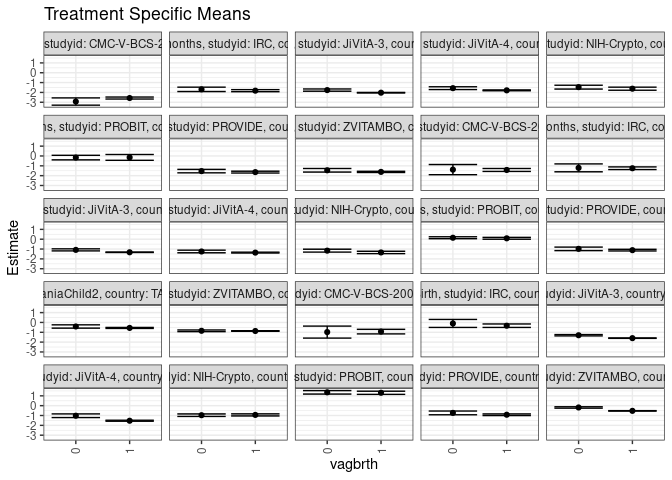

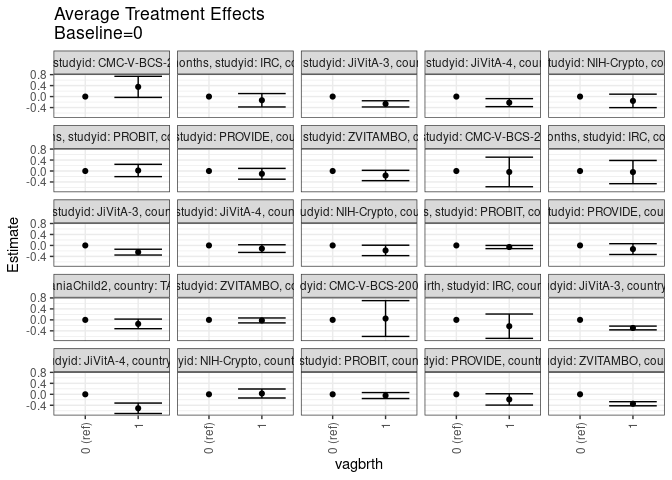

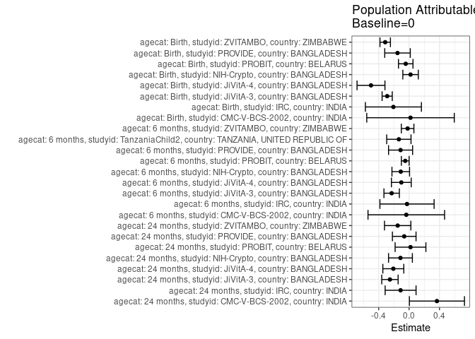

## Results Table

### Parameter: TSM

| agecat | studyid | country | intervention_level | baseline_level | estimate | ci_lower | ci_upper |
| --- | --- | --- | --- | --- | --- | --- | --- |
| Birth | CMC-V-BCS-2002 | INDIA | 0 | NA | -0.9799653 | -1.5901508 | -0.3697797 |
| Birth | CMC-V-BCS-2002 | INDIA | 1 | NA | -0.9316452 | -1.1630119 | -0.7002786 |
| Birth | IRC | INDIA | 0 | NA | -0.1016804 | -0.5083777 | 0.3050168 |
| Birth | IRC | INDIA | 1 | NA | -0.3328069 | -0.5087636 | -0.1568502 |
| Birth | JiVitA-3 | BANGLADESH | 0 | NA | -1.3010525 | -1.3689974 | -1.2331077 |
| Birth | JiVitA-3 | BANGLADESH | 1 | NA | -1.5965174 | -1.6160569 | -1.5769778 |
| Birth | JiVitA-4 | BANGLADESH | 0 | NA | -1.0219914 | -1.2066194 | -0.8373633 |
| Birth | JiVitA-4 | BANGLADESH | 1 | NA | -1.5314843 | -1.5818043 | -1.4811643 |
| Birth | NIH-Crypto | BANGLADESH | 0 | NA | -0.9675400 | -1.0956389 | -0.8394411 |
| Birth | NIH-Crypto | BANGLADESH | 1 | NA | -0.9383543 | -1.0432041 | -0.8335044 |
| Birth | PROBIT | BELARUS | 0 | NA | 1.3554823 | 1.1798062 | 1.5311585 |
| Birth | PROBIT | BELARUS | 1 | NA | 1.3097418 | 1.1484338 | 1.4710498 |
| Birth | PROVIDE | BANGLADESH | 0 | NA | -0.7328272 | -0.9230611 | -0.5425933 |
| Birth | PROVIDE | BANGLADESH | 1 | NA | -0.9199640 | -1.0012805 | -0.8386475 |
| Birth | ZVITAMBO | ZIMBABWE | 0 | NA | -0.1827360 | -0.2543949 | -0.1110772 |
| Birth | ZVITAMBO | ZIMBABWE | 1 | NA | -0.5271412 | -0.5486854 | -0.5055970 |
| 6 months | CMC-V-BCS-2002 | INDIA | 0 | NA | -1.3866814 | -1.9036482 | -0.8697146 |
| 6 months | CMC-V-BCS-2002 | INDIA | 1 | NA | -1.4216753 | -1.5687664 | -1.2745841 |
| 6 months | IRC | INDIA | 0 | NA | -1.2070980 | -1.6084402 | -0.8057557 |
| 6 months | IRC | INDIA | 1 | NA | -1.2462357 | -1.3829437 | -1.1095277 |
| 6 months | JiVitA-3 | BANGLADESH | 0 | NA | -1.0840780 | -1.1883574 | -0.9797986 |
| 6 months | JiVitA-3 | BANGLADESH | 1 | NA | -1.3279663 | -1.3512562 | -1.3046763 |
| 6 months | JiVitA-4 | BANGLADESH | 0 | NA | -1.2479706 | -1.3814548 | -1.1144863 |
| 6 months | JiVitA-4 | BANGLADESH | 1 | NA | -1.3626765 | -1.4065072 | -1.3188458 |
| 6 months | NIH-Crypto | BANGLADESH | 0 | NA | -1.1636618 | -1.3121430 | -1.0151805 |
| 6 months | NIH-Crypto | BANGLADESH | 1 | NA | -1.3455402 | -1.4646170 | -1.2264634 |
| 6 months | PROBIT | BELARUS | 0 | NA | 0.1483615 | 0.0503421 | 0.2463810 |
| 6 months | PROBIT | BELARUS | 1 | NA | 0.0905728 | -0.0017285 | 0.1828741 |
| 6 months | PROVIDE | BANGLADESH | 0 | NA | -0.9797980 | -1.1587312 | -0.8008649 |
| 6 months | PROVIDE | BANGLADESH | 1 | NA | -1.1131275 | -1.1963743 | -1.0298807 |
| 6 months | TanzaniaChild2 | TANZANIA, UNITED REPUBLIC OF | 0 | NA | -0.4110074 | -0.5791143 | -0.2429005 |
| 6 months | TanzaniaChild2 | TANZANIA, UNITED REPUBLIC OF | 1 | NA | -0.5571421 | -0.6086925 | -0.5055916 |
| 6 months | ZVITAMBO | ZIMBABWE | 0 | NA | -0.8492289 | -0.9353925 | -0.7630653 |
| 6 months | ZVITAMBO | ZIMBABWE | 1 | NA | -0.8702546 | -0.8971993 | -0.8433099 |
| 24 months | CMC-V-BCS-2002 | INDIA | 0 | NA | -2.9253153 | -3.2943681 | -2.5562625 |
| 24 months | CMC-V-BCS-2002 | INDIA | 1 | NA | -2.5703267 | -2.6731419 | -2.4675114 |
| 24 months | IRC | INDIA | 0 | NA | -1.6871480 | -1.9086024 | -1.4656937 |
| 24 months | IRC | INDIA | 1 | NA | -1.8212786 | -1.9242662 | -1.7182911 |
| 24 months | JiVitA-3 | BANGLADESH | 0 | NA | -1.7623960 | -1.8745762 | -1.6502159 |
| 24 months | JiVitA-3 | BANGLADESH | 1 | NA | -2.0277463 | -2.0553562 | -2.0001363 |
| 24 months | JiVitA-4 | BANGLADESH | 0 | NA | -1.5660486 | -1.7092337 | -1.4228635 |
| 24 months | JiVitA-4 | BANGLADESH | 1 | NA | -1.7872169 | -1.8268747 | -1.7475591 |
| 24 months | NIH-Crypto | BANGLADESH | 0 | NA | -1.4641636 | -1.6581729 | -1.2701542 |
| 24 months | NIH-Crypto | BANGLADESH | 1 | NA | -1.6214509 | -1.7774704 | -1.4654314 |
| 24 months | PROBIT | BELARUS | 0 | NA | -0.1631924 | -0.3949606 | 0.0685758 |
| 24 months | PROBIT | BELARUS | 1 | NA | -0.1444782 | -0.4378743 | 0.1489178 |
| 24 months | PROVIDE | BANGLADESH | 0 | NA | -1.5384806 | -1.7122851 | -1.3646760 |
| 24 months | PROVIDE | BANGLADESH | 1 | NA | -1.6402303 | -1.7343982 | -1.5460624 |
| 24 months | ZVITAMBO | ZIMBABWE | 0 | NA | -1.4543643 | -1.6343474 | -1.2743812 |
| 24 months | ZVITAMBO | ZIMBABWE | 1 | NA | -1.6180626 | -1.6781517 | -1.5579736 |

### Parameter: E(Y)

| agecat | studyid | country | intervention_level | baseline_level | estimate | ci_lower | ci_upper |
| --- | --- | --- | --- | --- | --- | --- | --- |
| Birth | CMC-V-BCS-2002 | INDIA | NA | NA | -0.9611957 | -1.1776967 | -0.7446946 |
| Birth | IRC | INDIA | NA | NA | -0.3080412 | -0.4687931 | -0.1472894 |
| Birth | JiVitA-3 | BANGLADESH | NA | NA | -1.5892417 | -1.6084834 | -1.5700000 |
| Birth | JiVitA-4 | BANGLADESH | NA | NA | -1.5231680 | -1.5722488 | -1.4740872 |
| Birth | NIH-Crypto | BANGLADESH | NA | NA | -0.9480084 | -1.0301396 | -0.8658772 |
| Birth | PROBIT | BELARUS | NA | NA | 1.3114417 | 1.1524752 | 1.4704082 |
| Birth | PROVIDE | BANGLADESH | NA | NA | -0.8851020 | -0.9601332 | -0.8100709 |
| Birth | ZVITAMBO | ZIMBABWE | NA | NA | -0.4970772 | -0.5177022 | -0.4764523 |
| 6 months | CMC-V-BCS-2002 | INDIA | NA | NA | -1.4234508 | -1.5645974 | -1.2823042 |
| 6 months | IRC | INDIA | NA | NA | -1.2344062 | -1.3658524 | -1.1029600 |
| 6 months | JiVitA-3 | BANGLADESH | NA | NA | -1.3134013 | -1.3366073 | -1.2901952 |
| 6 months | JiVitA-4 | BANGLADESH | NA | NA | -1.3500888 | -1.3921730 | -1.3080047 |
| 6 months | NIH-Crypto | BANGLADESH | NA | NA | -1.2731619 | -1.3626957 | -1.1836282 |
| 6 months | PROBIT | BELARUS | NA | NA | 0.0980074 | 0.0062724 | 0.1897424 |
| 6 months | PROVIDE | BANGLADESH | NA | NA | -1.0916915 | -1.1661176 | -1.0172654 |
| 6 months | TanzaniaChild2 | TANZANIA, UNITED REPUBLIC OF | NA | NA | -0.5455565 | -0.5948696 | -0.4962435 |
| 6 months | ZVITAMBO | ZIMBABWE | NA | NA | -0.8685914 | -0.8942954 | -0.8428875 |
| 24 months | CMC-V-BCS-2002 | INDIA | NA | NA | -2.5588679 | -2.6583730 | -2.4593629 |
| 24 months | IRC | INDIA | NA | NA | -1.7987775 | -1.8923914 | -1.7051636 |
| 24 months | JiVitA-3 | BANGLADESH | NA | NA | -2.0144245 | -2.0420946 | -1.9867544 |
| 24 months | JiVitA-4 | BANGLADESH | NA | NA | -1.7734527 | -1.8119258 | -1.7349797 |
| 24 months | NIH-Crypto | BANGLADESH | NA | NA | -1.5776538 | -1.6988448 | -1.4564629 |
| 24 months | PROBIT | BELARUS | NA | NA | -0.1442891 | -0.4253755 | 0.1367972 |
| 24 months | PROVIDE | BANGLADESH | NA | NA | -1.6024221 | -1.6857420 | -1.5191023 |
| 24 months | ZVITAMBO | ZIMBABWE | NA | NA | -1.6043391 | -1.6616652 | -1.5470130 |

### Parameter: ATE

| agecat | studyid | country | intervention_level | baseline_level | estimate | ci_lower | ci_upper |
| --- | --- | --- | --- | --- | --- | --- | --- |
| Birth | CMC-V-BCS-2002 | INDIA | 0 | 0 | 0.0000000 | 0.0000000 | 0.0000000 |
| Birth | CMC-V-BCS-2002 | INDIA | 1 | 0 | 0.0483200 | -0.6039482 | 0.7005882 |
| Birth | IRC | INDIA | 0 | 0 | 0.0000000 | 0.0000000 | 0.0000000 |
| Birth | IRC | INDIA | 1 | 0 | -0.2311265 | -0.6742786 | 0.2120256 |
| Birth | JiVitA-3 | BANGLADESH | 0 | 0 | 0.0000000 | 0.0000000 | 0.0000000 |
| Birth | JiVitA-3 | BANGLADESH | 1 | 0 | -0.2954648 | -0.3646004 | -0.2263293 |
| Birth | JiVitA-4 | BANGLADESH | 0 | 0 | 0.0000000 | 0.0000000 | 0.0000000 |
| Birth | JiVitA-4 | BANGLADESH | 1 | 0 | -0.5094930 | -0.6996190 | -0.3193669 |
| Birth | NIH-Crypto | BANGLADESH | 0 | 0 | 0.0000000 | 0.0000000 | 0.0000000 |
| Birth | NIH-Crypto | BANGLADESH | 1 | 0 | 0.0291857 | -0.1349374 | 0.1933089 |
| Birth | PROBIT | BELARUS | 0 | 0 | 0.0000000 | 0.0000000 | 0.0000000 |
| Birth | PROBIT | BELARUS | 1 | 0 | -0.0457405 | -0.1539948 | 0.0625138 |
| Birth | PROVIDE | BANGLADESH | 0 | 0 | 0.0000000 | 0.0000000 | 0.0000000 |
| Birth | PROVIDE | BANGLADESH | 1 | 0 | -0.1871368 | -0.3935073 | 0.0192337 |
| Birth | ZVITAMBO | ZIMBABWE | 0 | 0 | 0.0000000 | 0.0000000 | 0.0000000 |
| Birth | ZVITAMBO | ZIMBABWE | 1 | 0 | -0.3444051 | -0.4191060 | -0.2697043 |
| 6 months | CMC-V-BCS-2002 | INDIA | 0 | 0 | 0.0000000 | 0.0000000 | 0.0000000 |
| 6 months | CMC-V-BCS-2002 | INDIA | 1 | 0 | -0.0349939 | -0.5749293 | 0.5049416 |
| 6 months | IRC | INDIA | 0 | 0 | 0.0000000 | 0.0000000 | 0.0000000 |
| 6 months | IRC | INDIA | 1 | 0 | -0.0391377 | -0.4626980 | 0.3844226 |
| 6 months | JiVitA-3 | BANGLADESH | 0 | 0 | 0.0000000 | 0.0000000 | 0.0000000 |
| 6 months | JiVitA-3 | BANGLADESH | 1 | 0 | -0.2438883 | -0.3495284 | -0.1382482 |
| 6 months | JiVitA-4 | BANGLADESH | 0 | 0 | 0.0000000 | 0.0000000 | 0.0000000 |
| 6 months | JiVitA-4 | BANGLADESH | 1 | 0 | -0.1147060 | -0.2543975 | 0.0249856 |
| 6 months | NIH-Crypto | BANGLADESH | 0 | 0 | 0.0000000 | 0.0000000 | 0.0000000 |
| 6 months | NIH-Crypto | BANGLADESH | 1 | 0 | -0.1818784 | -0.3722807 | 0.0085238 |
| 6 months | PROBIT | BELARUS | 0 | 0 | 0.0000000 | 0.0000000 | 0.0000000 |
| 6 months | PROBIT | BELARUS | 1 | 0 | -0.0577887 | -0.1158081 | 0.0002308 |
| 6 months | PROVIDE | BANGLADESH | 0 | 0 | 0.0000000 | 0.0000000 | 0.0000000 |
| 6 months | PROVIDE | BANGLADESH | 1 | 0 | -0.1333295 | -0.3301330 | 0.0634740 |
| 6 months | TanzaniaChild2 | TANZANIA, UNITED REPUBLIC OF | 0 | 0 | 0.0000000 | 0.0000000 | 0.0000000 |
| 6 months | TanzaniaChild2 | TANZANIA, UNITED REPUBLIC OF | 1 | 0 | -0.1461347 | -0.3211006 | 0.0288313 |
| 6 months | ZVITAMBO | ZIMBABWE | 0 | 0 | 0.0000000 | 0.0000000 | 0.0000000 |
| 6 months | ZVITAMBO | ZIMBABWE | 1 | 0 | -0.0210257 | -0.1108335 | 0.0687821 |
| 24 months | CMC-V-BCS-2002 | INDIA | 0 | 0 | 0.0000000 | 0.0000000 | 0.0000000 |
| 24 months | CMC-V-BCS-2002 | INDIA | 1 | 0 | 0.3549886 | -0.0299081 | 0.7398854 |
| 24 months | IRC | INDIA | 0 | 0 | 0.0000000 | 0.0000000 | 0.0000000 |
| 24 months | IRC | INDIA | 1 | 0 | -0.1341306 | -0.3779659 | 0.1097047 |
| 24 months | JiVitA-3 | BANGLADESH | 0 | 0 | 0.0000000 | 0.0000000 | 0.0000000 |
| 24 months | JiVitA-3 | BANGLADESH | 1 | 0 | -0.2653502 | -0.3781282 | -0.1525723 |
| 24 months | JiVitA-4 | BANGLADESH | 0 | 0 | 0.0000000 | 0.0000000 | 0.0000000 |
| 24 months | JiVitA-4 | BANGLADESH | 1 | 0 | -0.2211683 | -0.3675505 | -0.0747861 |
| 24 months | NIH-Crypto | BANGLADESH | 0 | 0 | 0.0000000 | 0.0000000 | 0.0000000 |
| 24 months | NIH-Crypto | BANGLADESH | 1 | 0 | -0.1572873 | -0.4022211 | 0.0876465 |
| 24 months | PROBIT | BELARUS | 0 | 0 | 0.0000000 | 0.0000000 | 0.0000000 |
| 24 months | PROBIT | BELARUS | 1 | 0 | 0.0187141 | -0.2057546 | 0.2431829 |
| 24 months | PROVIDE | BANGLADESH | 0 | 0 | 0.0000000 | 0.0000000 | 0.0000000 |
| 24 months | PROVIDE | BANGLADESH | 1 | 0 | -0.1017497 | -0.2982139 | 0.0947145 |
| 24 months | ZVITAMBO | ZIMBABWE | 0 | 0 | 0.0000000 | 0.0000000 | 0.0000000 |
| 24 months | ZVITAMBO | ZIMBABWE | 1 | 0 | -0.1636984 | -0.3522469 | 0.0248502 |

### Parameter: PAR

| agecat | studyid | country | intervention_level | baseline_level | estimate | ci_lower | ci_upper |
| --- | --- | --- | --- | --- | --- | --- | --- |
| Birth | CMC-V-BCS-2002 | INDIA | 0 | NA | 0.0187696 | -0.5570913 | 0.5946305 |
| Birth | IRC | INDIA | 0 | NA | -0.2063608 | -0.5749459 | 0.1622242 |
| Birth | JiVitA-3 | BANGLADESH | 0 | NA | -0.2881891 | -0.3549901 | -0.2213882 |
| Birth | JiVitA-4 | BANGLADESH | 0 | NA | -0.5011766 | -0.6847588 | -0.3175944 |
| Birth | NIH-Crypto | BANGLADESH | 0 | NA | 0.0195316 | -0.0823581 | 0.1214213 |
| Birth | PROBIT | BELARUS | 0 | NA | -0.0440406 | -0.1395178 | 0.0514366 |
| Birth | PROVIDE | BANGLADESH | 0 | NA | -0.1522749 | -0.3202566 | 0.0157068 |
| Birth | ZVITAMBO | ZIMBABWE | 0 | NA | -0.3143412 | -0.3831489 | -0.2455335 |
| 6 months | CMC-V-BCS-2002 | INDIA | 0 | NA | -0.0367694 | -0.5406576 | 0.4671188 |
| 6 months | IRC | INDIA | 0 | NA | -0.0273082 | -0.3840385 | 0.3294220 |
| 6 months | JiVitA-3 | BANGLADESH | 0 | NA | -0.2293233 | -0.3308191 | -0.1278275 |
| 6 months | JiVitA-4 | BANGLADESH | 0 | NA | -0.1021183 | -0.2322967 | 0.0280601 |
| 6 months | NIH-Crypto | BANGLADESH | 0 | NA | -0.1095002 | -0.2253972 | 0.0063969 |
| 6 months | PROBIT | BELARUS | 0 | NA | -0.0503541 | -0.1013479 | 0.0006396 |
| 6 months | PROVIDE | BANGLADESH | 0 | NA | -0.1118935 | -0.2701711 | 0.0463842 |
| 6 months | TanzaniaChild2 | TANZANIA, UNITED REPUBLIC OF | 0 | NA | -0.1345491 | -0.2945720 | 0.0254737 |
| 6 months | ZVITAMBO | ZIMBABWE | 0 | NA | -0.0193625 | -0.1021672 | 0.0634421 |
| 24 months | CMC-V-BCS-2002 | INDIA | 0 | NA | 0.3664474 | 0.0040344 | 0.7288603 |
| 24 months | IRC | INDIA | 0 | NA | -0.1116295 | -0.3150408 | 0.0917819 |
| 24 months | JiVitA-3 | BANGLADESH | 0 | NA | -0.2520285 | -0.3597935 | -0.1442634 |
| 24 months | JiVitA-4 | BANGLADESH | 0 | NA | -0.2074041 | -0.3453657 | -0.0694425 |
| 24 months | NIH-Crypto | BANGLADESH | 0 | NA | -0.1134903 | -0.2703229 | 0.0433423 |
| 24 months | PROBIT | BELARUS | 0 | NA | 0.0189032 | -0.1834417 | 0.2212482 |
| 24 months | PROVIDE | BANGLADESH | 0 | NA | -0.0639416 | -0.2194330 | 0.0915498 |
| 24 months | ZVITAMBO | ZIMBABWE | 0 | NA | -0.1499748 | -0.3235986 | 0.0236489 |